# Notebook

```python
import importlib
from typing import Dict
from matplotlib import pyplot as plt
from shared.definitions import TuningResult
from shared.ml_config_core import ModelTrainingResult
from shared import stats_utils
from shared.ml_config_runner import build_production_model_for_tuning_result
from src import data_loader
from shared import graph
from shared import utils
import seaborn as sns
import pandas as pd
import xgboost
```

```python
VERBOSE = False
```

```python
utils.pandas_config(pd)
utils.plt_config(plt)

sns.set_theme(style="darkgrid", palette="pastel")
plt.style.use("fivethirtyeight")
```

```python
# Use this to select the model to train, gennerally there are certain advantages and disadvantages between using different tuning targets:
# e.g. F1 provides better classification accuracy
# PR-AUC however is only slightly worse but has much smoother probabilities which is more
# useful when when selecting thresholds for grades
INCLUDE_MODELS = [
    "BaselineOnlyEmplDuration",
    "XGBoostTuneF1Rejected",
    # "XGBoostTunePRAUCRejected",
    # "CatBoostF1",
    # "XGBoostTuneF1",
]
```

# 2.1.1 Predicting Rejected Loans

Our first model is used to predict whether a loan application was accepted or rejected. It uses a table that was merged from the accepted and rejected loan (only the independent variables that are available in both are included).

`Accepted/Rejected is encoded as 1/0 in our traing/test samples`

### 2.1.1.1 Model Selection and Hypertuning

We've experimented using multiple models:

- `XGBoost`
- `LGBM`
- `CatBoost`

And multiple tuning target metrics:

- `F1`
- `PR-AUC`
- `LogLoss`

When predicting rejected application we have achieved the best performance when using an XGBoost (as fast or faster than CatBoost and LGBM with slightly better performance) tuning to maximize F1.

see the appendices for more details.

### 2.1.1.2 Training and Evaluating the Accepted/Rejected Application Model

The dataset is pre-split into a 20% test sample and a 80% training sample.

Overall our goal was to maximize the macro F1 (we have no reasons to priortize the accuracy for either class because the model doesn't really have any practical applications besides estimating the algorithm Lenders Club is using to reject applications and any potential biases that it might contain).

Additionally, we've also used PR-AUC to evaluate our model, it quantifies a classifier's ability to distinguish between classes under varying thresholds (however this will be more relevant for the default risk estimation model).

```python
importlib.reload(data_loader)
transformed_data = data_loader.load_processed_dataset(
    target_dataset=data_loader.TargetDataset.MergedRejectedAccepted,
    sample_size=data_loader.SampleSize.Full,
    tuning_df=True,
    target_col="Accepted",
    drop_cols=["policy_code"],
)

if VERBOSE:
    print(f"Total Samples Loaded: {len(transformed_data)}")
```

```
With transform="pandas", `func` should return a DataFrame to follow the set_output API.
```

```python
cv_results_all_models: Dict[str, ModelTrainingResult] = {}

for model_key in INCLUDE_MODELS:
    tuning_result = TuningResult.load_serialized_tuning_result(model_key)

    cv_results = build_production_model_for_tuning_result(
        tuning_result=tuning_result, df=transformed_data
    )
    cv_results_all_models[model_key] = cv_results

    ModelTrainingResult.serialize_model(cv_results, model_key)
```

```
Training: XGBoostTuneF1 with: {'feat_trans_dummytransformer__option': 1, 'model__scale_pos_weight': 5, 'model__n_estimators': 150, 'model__min_child_weight': 2, 'model__max_depth': 7, 'model__learning_rate': 1, 'model__gamma': 0.1}
BaselineOnlyEmplDuration: 45.2 seconds
Training: XGBoostTuneF1 with: {'feat_trans_dummytransformer__option': 0, 'model__scale_pos_weight': 2, 'model__n_estimators': 200, 'model__min_child_weight': 3, 'model__max_depth': 4, 'model__learning_rate': 0.5, 'model__gamma': 0.05}
XGBoostTuneF1Rejected: 187.2 seconds
```

The models were trained using 5-Fold CV validation. We've evaluated them using a 20% test split (considering the size of the dataset using a much smaller test split would probably be acceptable):

```python
for model_key, model_results in cv_results_all_models.items():
    display(model_key)
    display("CV Results:")
    display(pd.Series(model_results.cv_metrics).round(3))
    display("Test Split Evaluation:")
    display(pd.Series(model_results.test_data.metrics).round(3))
```

```
'BaselineOnlyEmplDuration'
```

```
'CV Results:'
```

```
accuracy                 0.875
precision_macro          0.871
recall_macro             0.862
f1_macro                 0.866
f1_micro                 0.875
target_f1                0.900
target_recall            0.916
target_precision         0.885
fbeta_1.5                0.906
fbeta_2.5                0.911
fbeta_4.0                0.914
log_loss                 0.509
n_samples           586038.000
dtype: float64
```

```
'Test Split Evaluation:'
```

```
f1                   0.875
f1_macro             0.866
accuracy             0.875
precision            0.871
recall               0.862
recall_class_1       0.916
precision_class_1    0.886
f1_class_1           0.901
fbeta_25             0.912
log_loss             0.506
dtype: float64
```

```
'XGBoostTuneF1Rejected'
```

```
'CV Results:'
```

```
accuracy                 0.944
precision_macro          0.948
recall_macro             0.933
f1_macro                 0.939
f1_micro                 0.944
target_f1                0.955
target_recall            0.978
target_precision         0.934
fbeta_1.5                0.964
fbeta_2.5                0.972
fbeta_4.0                0.975
log_loss                 0.165
n_samples           586038.000
dtype: float64
```

```
'Test Split Evaluation:'
```

```
f1                   0.945
f1_macro             0.941
accuracy             0.945
precision            0.950
recall               0.935
recall_class_1       0.979
precision_class_1    0.936
f1_class_1           0.957
fbeta_25             0.973
log_loss             0.160
dtype: float64
```

```
The figure layout has changed to tight
```

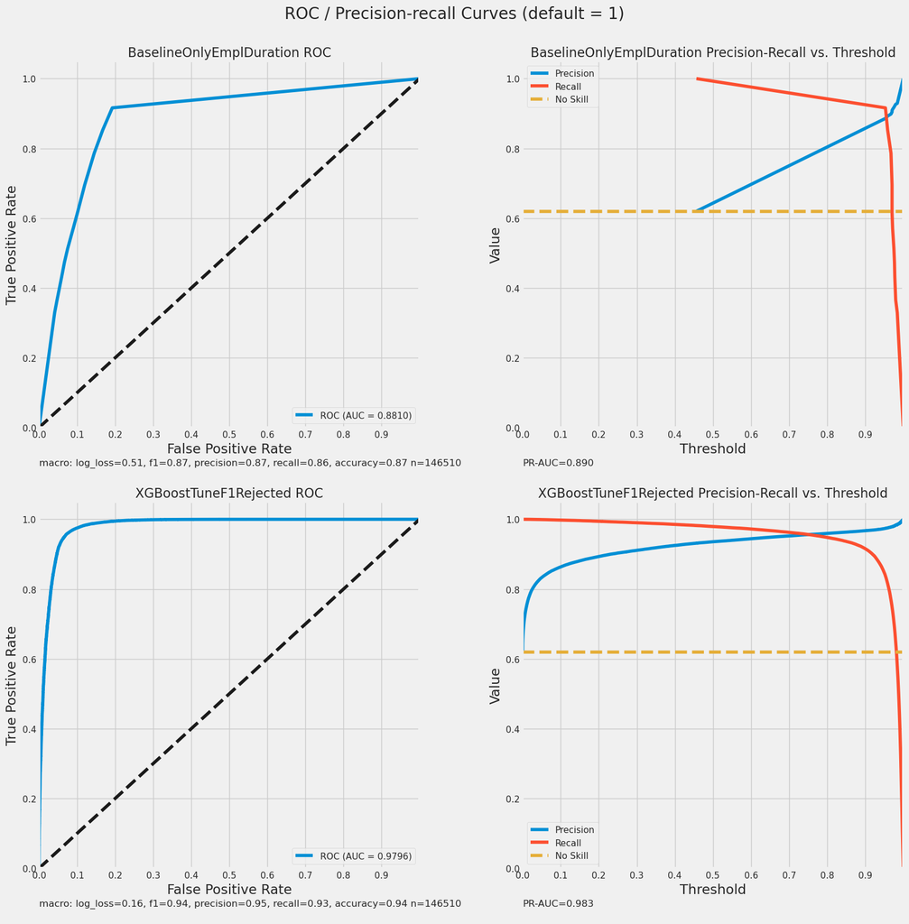

```python
importlib.reload(graph)
first_model = list(cv_results_all_models.keys())[0]
graph.roc_precision_recal_grid_plot(cv_results_all_models)
```

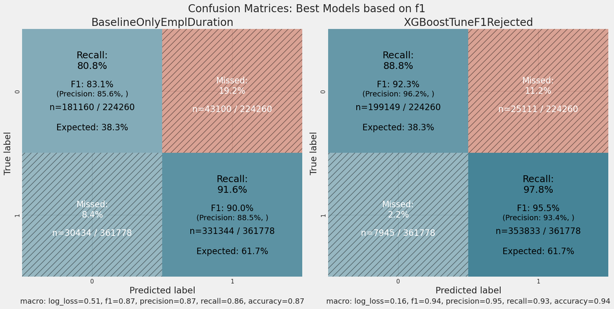

```python
importlib.reload(graph)

n = len(cv_results_all_models)
columns = 2
rows = (n + 1) // columns
height = 8
width = height * columns

fig, axes = plt.subplots(
    rows, columns, figsize=(width, height * rows), constrained_layout=True
)
plt.suptitle("Confusion Matrices: Best Models based on f1", fontsize=20)

axes_flat = axes.flatten()
for i, model_key in enumerate(cv_results_all_models.keys()):
    graph.confusion_matrix_plot_v2(
        cv_results_all_models[model_key].cm_data,
        title=model_key,
        annotations=graph.make_annotations(cv_results_all_models[model_key].cv_metrics),
        ax=axes_flat[i],
    )

# Hide any unused axes
for j in range(i + 1, len(axes_flat)):
    axes_flat[j].axis("off")

plt.show()
```

We can see that our model is signficantly better at predicting positive (i.e. loan accepted) than negative cases, with quite a few rejected cases being misclassified as accepted. We could potentially use different hyper-parameters to optimize for precision instead of overal predictive power if our business problem required that (we'll see some example of that when building the Default Risk model in part next section (`2.2`)

```
set_ticklabels() should only be used with a fixed number of ticks, i.e. after set_ticks() or using a FixedLocator.
```

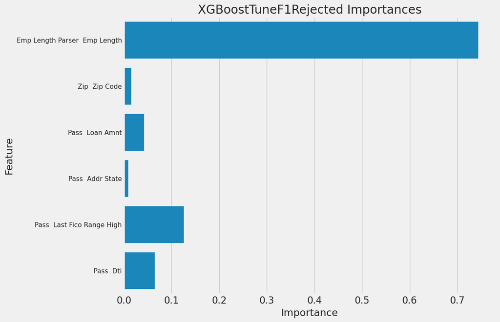

```python
importlib.reload(stats_utils)
for model_key in cv_results_all_models.keys():
    if "Baseline" in model_key:
        continue
    model_config = cv_results_all_models[model_key]
    feature_importances = stats_utils.get_model_feature_importances(
        model_config, transformed_data
    )

    graph.render_feature_importances_chart(
        feature_importances=feature_importances,
        title=f"{model_key} Importances",
    )
    if VERBOSE:
        display(feature_importances)
```

```python
from shared import pipeline

features_all, labels_all = pipeline._get_features_labels(transformed_data)
X_train, X_test, y_train, y_test = pipeline.get_deterministic_train_test_split(
    features_all, labels_all
)

X_train = X_train.drop(columns=["target__Accepted"])
X_test = X_test.drop(columns=["target__Accepted"])
```

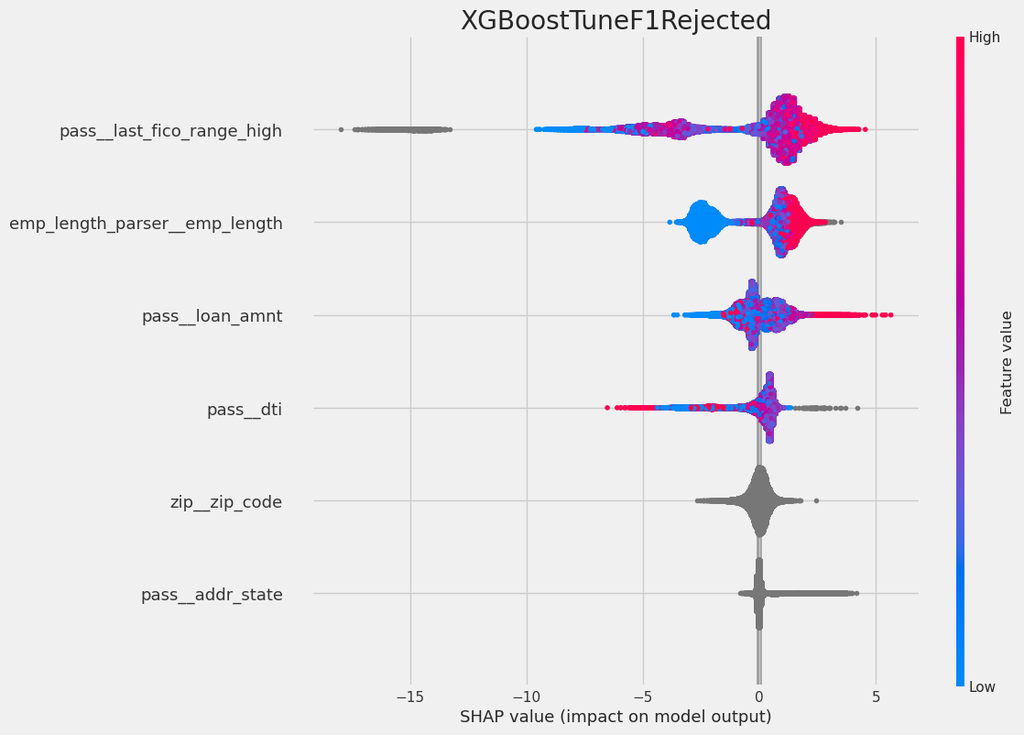

```python
importlib.reload(graph)
for model_key, model_data in cv_results_all_models.items():
    if "Baseline" in model_key:
        continue

    model = cv_results_all_models[model_key].test_data.test_model.named_steps["model"]

    booster_model = model.get_booster()
    shap_values = booster_model.predict(
        xgboost.DMatrix(X_test, enable_categorical=True), pred_contribs=True
    )
    graph.render_shap_plot(shap_values, X_test, model_title=model_key)
```

### 2.1.1.3 Conclusion

The model performance achieved using XGBoost is statisfactory (we've tried LGBM and Catboost and the performance was comparable). We've found that the Lending Club mainly bases their decision of whether to accept or decline an application based on the number years the application was employed:

- Almost all the applications `Employment Length` <= 1 are rejected (which is the majority of the rejected loans). So a dummy baseline model that only uses this variable is able to achieve ~87% accuracy and 0.87 macro F1.
- Using additional features can explain the remainder of the rejections (mainly `Debt-To-Income Ratio` and `Risk_Score` and `Amount Requested`) to some extent. Adding them to our model improve the performance to 94%/0.94.
- If the algorithm/model used by the platform is fixed and only uses the same features even such high performance might be considered to be to poor. However, if we assume that their decision process is not 100% consistent and decisions can still be made on a case by case basis the performance is probably close to being as good as it can be.